# Relatório 09

Kaleb Aquino Mileib

12/04/2022

# 1 Objetivos

Nesta etapa do estudo, busca-se responder a uma série de questões fundamentais relacionadas ao planejamento, execução e interpretação de um experimento fatorial triplo. São abordados o total de combinações de tratamentos e número de repetições realizadas, bem como as vantagens de se utilizar um delineamento fatorial em comparação a experimentos isolados. Também se investiga a presença de interações entre os fatores e como elas influenciam a interpretação dos efeitos principais. Além disso, analisa-se qual combinação de fatores resulta no menor erro de posicionamento, quais fatores possuem maior influência no desempenho do sistema, e quais gráficos são mais adequados para apoiar a interpretação dos resultados. Por fim, são discutidas recomendações para aplicação industrial e a adequação do delineamento adotado frente a possíveis fontes de variação externas.

# 2 ANOVA

```r
# Carregar pacote
library(ExpDes.pt)

# Criar o data frame com os dados
dados <- data.frame(
  motor = rep(c("Stepper", "Servo"), each = 30),
  controle = rep(rep(c("PID", "Fuzzy"), each = 15), 2),
  carga = rep(rep(c(0, 25, 50, 75, 100), each = 3), 4),
  erro = c(
    0.189,0.195,0.231, 0.231,0.233,0.264, 0.269,0.235,0.246,
    0.281,0.314,0.297, 0.328,0.322,0.309, 0.216,0.190,0.141,
    0.224,0.201,0.189, 0.226,0.209,0.215, 0.247,0.226,0.277,
    0.293,0.267,0.315, 0.159,0.144,0.168, 0.198,0.196,0.194,
    0.221,0.209,0.204, 0.242,0.236,0.246, 0.255,0.323,0.304,
    0.108,0.122,0.121, 0.176,0.158,0.165, 0.179,0.179,0.207,
    0.205,0.240,0.179, 0.262,0.252,0.254
  )
)

# Converter os fatores para fator (necessário para análise correta)
dados$motor <- factor(dados$motor)
dados$controle <- factor(dados$controle)
dados$carga <- factor(dados$carga)

# ANOVA com aov()
modelo_aov <- aov(erro ~ motor * controle * carga, data = dados)
summary(modelo_aov)
```

```
##                      Df  Sum Sq  Mean Sq F value   Pr(>F)
## motor                 1 0.02705 0.027051  72.575 1.59e-10 ***
## controle              1 0.01667 0.016667  44.715 5.13e-08 ***
## carga                 4 0.10792 0.026979  72.383  < 2e-16 ***
## motor:controle        1 0.00000 0.000004   0.011    0.915
## motor:carga           4 0.00139 0.000348   0.934    0.454
## controle:carga        4 0.00024 0.000060   0.161    0.957
## motor:controle:carga  4 0.00058 0.000144   0.386    0.817
## Residuals            40 0.01491 0.000373
## ---
## Signif. codes:  0 '***' 0.001 '**' 0.01 '*' 0.05 '.' 0.1 ' ' 1
```

```r
# Rodar análise fatorial tripla com ExpDes.pt
fat3.dic(
  fator1 = dados$motor,
  fator2 = dados$controle,
  fator3 = dados$carga,
  resp = dados$erro,
  quali = c(TRUE, TRUE, TRUE),
  mcomp = "tukey",
  fac.names = c("Motor", "Controle", "Carga"),
  sigT = 0.05,
  sigF = 0.05,
  unfold = NULL
)
```

```
## ------------------------------------------------------------------------
## Legenda:
## FATOR 1:  Motor
## FATOR 2:  Controle
## FATOR 3:  Carga
## ------------------------------------------------------------------------
##
## ------------------------------------------------------------------------
## Quadro da analise de variancia
## ------------------------------------------------------------------------
##                      GL      SQ      QM      Fc  Pr>Fc
## Motor                 1 0.02705 0.02705 72.5754      0
## Controle              1 0.01667 0.01667 44.7147      0
## Carga                 4 0.10792 0.02698 72.3828      0
## Motor*Controle        1 0.00000       0  0.0114 0.9153
## Motor*Carga           4 0.00139 0.00035  0.9336 0.4543
## Controle*Carga        4 0.00024   6e-05  0.1611 0.9568
## Motor*Controle*Carga  4 0.00058 0.00014  0.3858 0.8175
## Residuo              40 0.01491 0.00037
## Total                59 0.16876
## ------------------------------------------------------------------------
## CV = 8.59 %
##
## ------------------------------------------------------------------------
## Teste de normalidade dos residuos (Shapiro-Wilk)
## valor-p:  0.3601505
## De acordo com o teste de Shapiro-Wilk a 5% de significancia, os residuos podem ser considerados normais.
## ------------------------------------------------------------------------
##
## Interacao nao significativa: analisando os efeitos simples
## ------------------------------------------------------------------------
## Motor
## Teste de Tukey
## ------------------------------------------------------------------------
## Grupos Tratamentos Medias
## a     Stepper     0.246
##  b    Servo   0.2035333
## ------------------------------------------------------------------------
##
## Controle
## Teste de Tukey
## ------------------------------------------------------------------------
## Grupos Tratamentos Medias
## a     PID     0.2414333
##  b    Fuzzy   0.2081
## ------------------------------------------------------------------------
##
## Carga
## Teste de Tukey
## ------------------------------------------------------------------------
## Grupos Tratamentos Medias
## a     100     0.2903333
##  b    75      0.2491667
##   c   50      0.2165833
##   c   25      0.2024167
##    d      0   0.1653333
## ------------------------------------------------------------------------
```

# 3 Perguntas

## 3.1 Primeira Questão

**Qual é o total de combinações de tratamentos possíveis neste experimento? Quantas repetições foram realizadas por tratamento?**

O número de combinações possíveis neste experimento é de **20**. São 2 tipos de motor, 2 métodos de controle e 5 níveis de carga, logo 2x2x5 = 20.

Para cada tratamento, foram realizadas 3 repetições, aumentando o número de combinações para **60**.

## 3.2 Segunda Questão

**Qual é a principal vantagem de se utilizar um delineamento fatorial triplo em vez de três experimentos separados?**

Um delineamento fatorial triplo completo permite avaliar efeitos principais de cada fator separadamente; Detectar interações entre fatores, como eles se relacionam e afetam a variável de resposta; E maximizar a eficiência, pois extrai mais informações com menos experimentos do que se fossem realizados separadamente para cada fator.

## 3.3 Terceira Questão

**A interação entre os fatores foi significativa? Se sim, como isso influencia a interpretação dos efeitos principais?**

Com base nos resultados da ANOVA, nenhuma das interações entre os fatores foi significativa ao nível de 5% de significância. As interações motor × controle (p = 0.915), motor × carga (p = 0.454), controle × carga (p = 0.957) e motor × controle × carga (p = 0.817) apresentaram valores-p elevados, indicando ausência de interação estatisticamente significativa. Isso significa que os efeitos principais de cada fator podem ser interpretados de forma independente, pois um fator não depende dos demais.

## 3.6 Sexta Questão

**Quais gráficos você utilizaria para auxiliar a interpretação dos resultados? Explique o porquê.**

Para esta questão, foram utilizados gráficos Boxplot, de barras e gráficos de interação. Os dois primeiros mostram os valores de erro e sua distribuição em cada nível de motor e controle. Os gráficos de interação servem para realçar que não há ligação entre os 3 fatores, como comprovado pelo teste fatorial triplo.

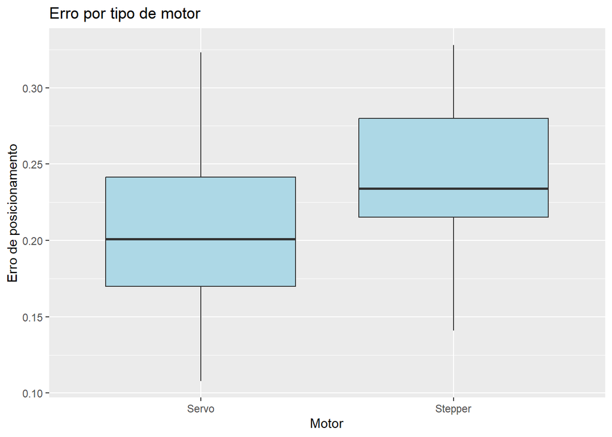

```r
# Carregar pacotes necessários
library(ggplot2)
library(dplyr)
# 1. Boxplot por fator isolado
ggplot(dados, aes(x = motor, y = erro)) +
  geom_boxplot(fill = "lightblue") +
  labs(title = "Erro por tipo de motor", x = "Motor", y = "Erro de posicionamento")
```

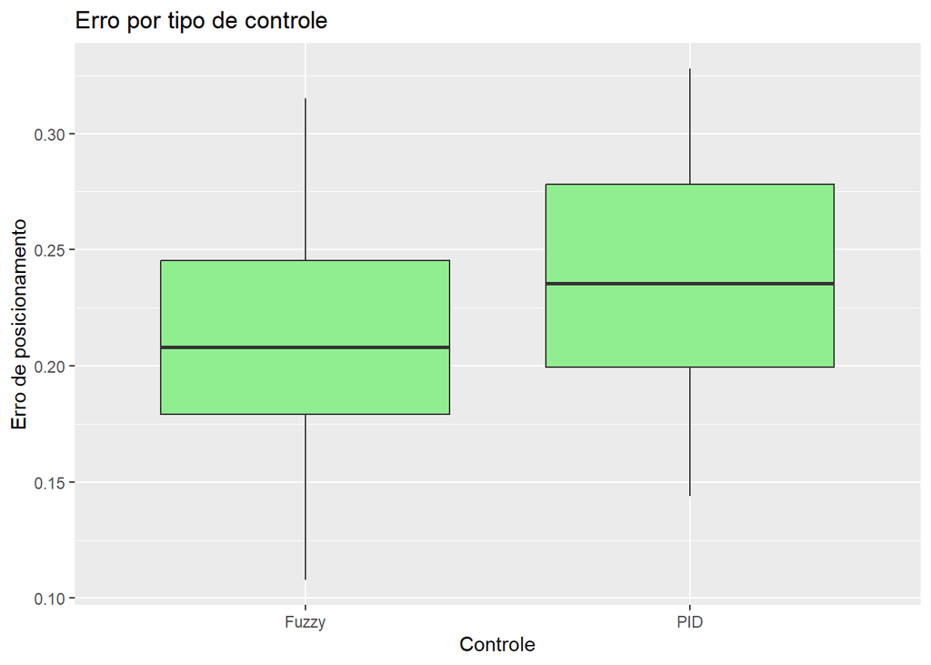

```r
ggplot(dados, aes(x = controle, y = erro)) +
  geom_boxplot(fill = "lightgreen") +
  labs(title = "Erro por tipo de controle", x = "Controle", y = "Erro de posicionamento")
```

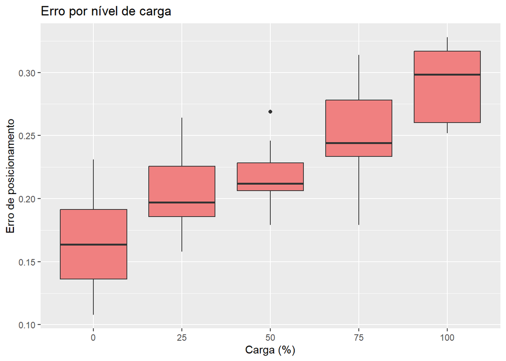

```r
ggplot(dados, aes(x = carga, y = erro)) +
  geom_boxplot(fill = "lightcoral") +
  labs(title = "Erro por nível de carga", x = "Carga (%)", y = "Erro de posicionamento")
```

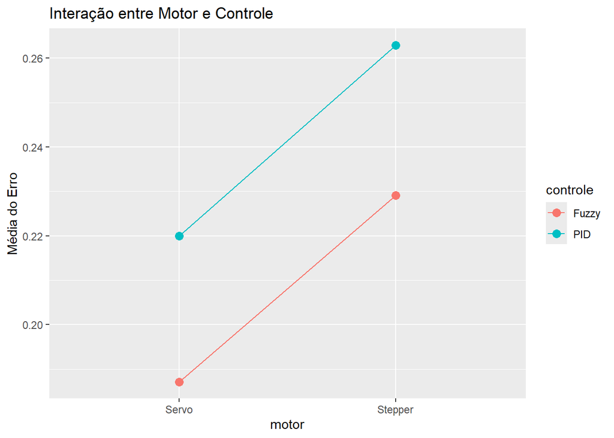

```r
# 2. Gráfico de interação: Motor x Controle
dados %>%
  group_by(motor, controle) %>%
  summarise(media_erro = mean(erro)) %>%
  ggplot(aes(x = motor, y = media_erro, color = controle, group = controle)) +
  geom_line() + geom_point(size = 3) +
  labs(title = "Interação entre Motor e Controle", y = "Média do Erro")
```